# Analyses for SII Experiment 1

### Sample Characteristics

We collected data from a total of N = 27 participants. Following our pre-registered exclusion criteria, we had to exclude no participants. This resulted in a sample of N = 27 participants (14 female, 13 male, 0 other, 0 not specified; average age M = 31.4 years, SD = 8.7, ranging from 18 to 54). Participants were recruited via the online platform Prolific (www.prolific.co) and received monetary compensation of 1.35 GBP for completing the 9-minute study. An additional 3 people started the experiment on prolific but either returned their submission, timed-out, or only partially completed the experiment due to technical issues.

On average, participants reported to be rather left leaning (M = 3.5, SD = 1.5 on a scale from 1 = left to 10 = right), rather interested in politics (M = 6.6, SD = 2.5, on a scale ranging from 1 = not at all to 10 = very strongly), and moderately satisfied with the German political system (M = 2.4, SD = 0.5, on a scale ranging from 1 = satisfied to 4 = dissatisfied).

### Preregistered analysis

```r
# Prepare rating data
rate <- d_long %>%
  select(subject_id, probe_type, rating) %>%
  mutate(probe_type = recode(probe_type,
    "implied" = "implied", "implied_other" = "implied other")) %>%
  group_by(probe_type, subject_id) %>%
  summarize(.groups = "drop_last", rating = mean(rating, na.rm = TRUE)) %>%
  # Find extreme outliers
  mutate(is_extreme = is_extreme(rating)) %>%
  ungroup() %T>%
  # Count participants that have extreme outliers
  assign(x = "rate_ex_n", envir = .GlobalEnv, value = n_distinct(
    select(filter(., is_extreme == TRUE), subject_id)))

# Create data frames where these rows are excluded
rate_ex <- filter(rate, is_extreme == FALSE)

# Descriptives
rate_desc <- rate_ex %>%
  group_by(probe_type) %>%
  get_summary_stats(rating, type = "mean_sd") %>%
  mutate(
    ci95_low = mean - 1.96 * sd / sqrt(n),
    ci95_upp = mean + 1.96 * sd / sqrt(n))

# One-sided paired t-test
rate_t <- rate_ex %>%
  t_test(
    rating ~ probe_type,
    paired = TRUE,
    alternative = "greater",
    ref.group = "implied")

# Cohens dz
rate_dz <- rate_ex %>%
  cohens_d(rating ~ probe_type,
    paired = TRUE, ref.group = "implied") %>%
  pull(effsize)

# Print t-test
rate_t_report <- paste0("t(", rate_t$df, ") = ", forma(rate_t$statistic),
  ", ", formp(rate_t$p, TRUE), ", d~z~ = ", forma(rate_dz))
rate_t_plot <- paste0("t(", rate_t$df, ") = ", forma(rate_t$statistic),
  ",\n", formp(rate_t$p, TRUE), ",\ndz = ", forma(rate_dz))
```

To prepare the ratings for analysis we computed the average for each experimental condition.

#### Outlier detection

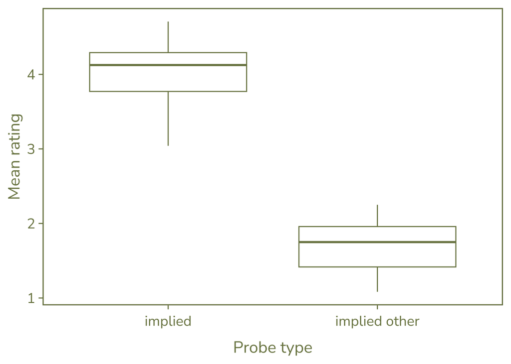

```r
rate_outlier_plot <- rate %>%
  ggplot(., aes(probe_type, rating)) +
  geom_boxplot(color = "#7A8450") +
  labs(x = "Probe type", y = "Mean rating") +
  theme_cs_talk()
rate_outlier_plot
```

We looked for extreme outliers in each cell of the design. We defined them as values above Q3 + 3 * IQR or below Q1 - 3 * IQR. We found and excluded 0 participants whose values were extreme outliers.

#### QQ-Plot

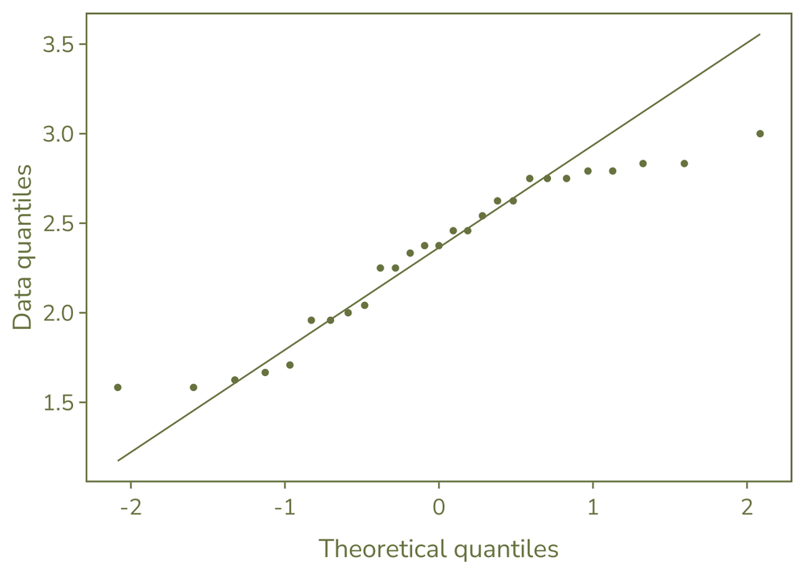

```r
rate_qq_plot <- rate_ex %>%
  pivot_wider(names_from = probe_type, values_from = rating) %>%
  mutate(diff = implied - `implied other`) %>%
  ggplot(., aes(sample = diff)) +
  labs(x = "Theoretical quantiles", y = "Data quantiles") +
  stat_qq(color = "#7A8450") +
  stat_qq_line(color = "#7A8450") +
  theme_cs_talk()
rate_qq_plot
```

Upon visual inspection the differences between the implied and implied-other conditions did not seem severely non-normal. We therefore applied no transformations before conducting a paired t-test.

#### T-test

On average, participants attributed the implied labels (M = 4.03, SD = 0.42) to a stronger extent than the implied other labels (M = 1.70, SD = 0.34), t(26) = 27.4, p < .001, d<sub>z</sub> = 5.27. This indicates that participants indeed inferred the labels that were implied in the statements.

#### Descriptives

```r
knitr::kable(rate_desc, format = "markdown")
```

| probe_type | variable | n | mean | sd | ci95_low | ci95_upp |
| --- | --- | --- | --- | --- | --- | --- |
| implied | rating | 27 | 4.029 | 0.416 | 3.872084 | 4.185916 |
| implied other | rating | 27 | 1.699 | 0.345 | 1.568865 | 1.829135 |

#### Barplot

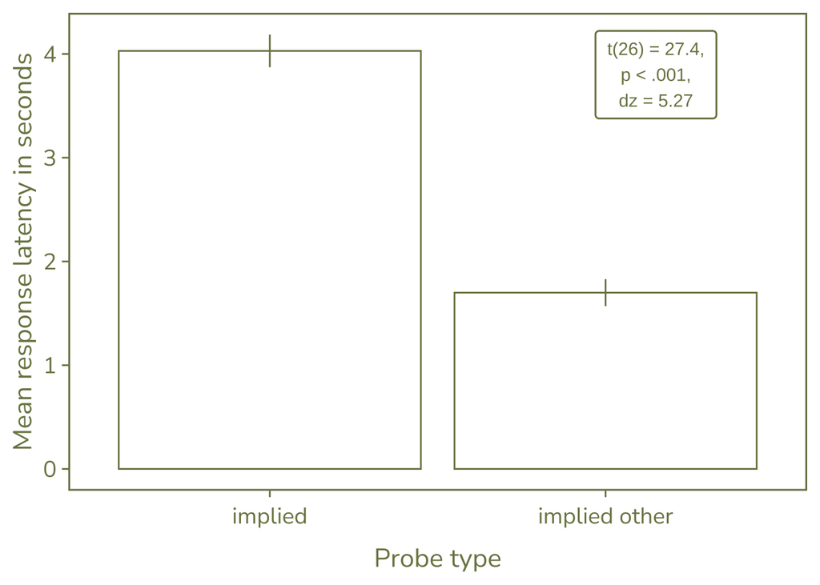

```r
rate_barplot <- rate_desc %>%
  ggplot(., aes(probe_type, mean)) +
  labs(x = "Probe type", y = "Mean response latency in seconds") +
  geom_bar(stat = "identity", color = "#7A8450", fill = "white") +
  geom_linerange(aes(ymin = ci95_low, ymax = ci95_upp), color = "#7A8450") +
  geom_label(aes(x = 2.15, y = 3.8, label = rate_t_plot),
    fill = "white", color = "#7A8450", show.legend = FALSE,
    label.padding = unit(0.5, "lines"), label.size = 0.5) +
  theme_cs_talk()
rate_barplot
```

### Exploratory by-item and analyses

To investigate whether the effect occurred for all items rather than just for a few, we computed a one-tailed dependent samples t-test for each item independently. Inference effects were significant for all 24 items (all ps < .001, dz ranging from 0.78 to 5.36).

#### Item analysis

```r
item_results <- data.frame()
for (id in unique(d_long$item_id)) {
  sub <- d_long %>%
    filter(item_id == id) %>%
    select(item_id, subject_id, label = probe, probe_type, rating)

  # Descriptives
  sub_desc <- sub %>%
    group_by(item_id, probe_type, label) %>%
    get_summary_stats(rating, type = "mean") %>%
    pivot_wider(names_from = probe_type, values_from = c(mean, label)) %>%
    mutate(inference_effect = mean_implied - mean_implied_other) %>%
    select(item_id, implied = mean_implied, implied_other = mean_implied_other,
      inference_effect, label_implied, label_implied_other)

  # One-sided paired t-test
  sub_t <- sub %>%
    t_test(
      rating ~ probe_type,
      paired = TRUE,
      alternative = "greater",
      ref.group = "implied") %>%
    rename(t = statistic) %>%
    select(-.y., -group1, -group2, -n1, -n2)

  # Cohens dz
  sub_dz <- sub %>%
    cohens_d(rating ~ probe_type,
      paired = TRUE, ref.group = "implied") %>%
    select(`cohen's dz` = effsize)

  # Merge
  sub_all <- cbind(sub_desc, sub_t, sub_dz)
  item_results <- rbind(item_results, sub_all)
}

item_results <- item_results %>%
  rowwise() %>%
  mutate(across(
    c(implied, implied_other, inference_effect, t, `cohen's dz`), forma)) %>%
  mutate(p = formp(p))

knitr::kable(item_results, format = "markdown")
```

| item_id | implied | implied_other | inference_effect | label_implied | label_implied_other | t | df | p | cohen’s dz |
| --- | --- | --- | --- | --- | --- | --- | --- | --- | --- |
| sexist_3 | 3.33 | 1.96 | 1.37 | Sexist | Pazifist | 4.05 | 26 | <.001 | 0.78 |
| querdenker_2 | 3.89 | 1.74 | 2.15 | Querdenkerin | Kommunistin | 8.64 | 26 | <.001 | 1.66 |
| gruen_1 | 4.30 | 1.11 | 3.19 | grün | Sexistin | 18.8 | 26 | <.001 | 3.62 |
| konservativ_1 | 4.41 | 2.26 | 2.15 | konservativ | Klimaleugnerin | 7.51 | 26 | <.001 | 1.45 |
| pazifist_1 | 4.48 | 1.41 | 3.07 | Pazifist | AfDler | 17.4 | 26 | <.001 | 3.35 |
| trumpist_1 | 4.63 | 2.30 | 2.33 | Trumpist | Incel | 10.0 | 26 | <.001 | 1.93 |
| verschwoerungstheoretiker_1 | 3.93 | 1.96 | 1.96 | Verschwörungstheoretikerin | Feministin | 8.55 | 26 | <.001 | 1.65 |
| incel_1 | 3.85 | 1.33 | 2.52 | Incel | Punk | 11.7 | 26 | <.001 | 2.24 |
| liberal_1 | 4.15 | 1.78 | 2.37 | liberal | Rassistin | 11.4 | 26 | <.001 | 2.20 |
| afdler_1 | 4.07 | 1.26 | 2.82 | AfDler | links | 14.6 | 26 | <.001 | 2.81 |
| rassist_7 | 4.00 | 1.44 | 2.56 | Rassistin | Hippie | 11.8 | 26 | <.001 | 2.28 |
| hippie_1 | 3.63 | 1.96 | 1.67 | Hippie | konservativ | 8.06 | 26 | <.001 | 1.55 |
| links_4 | 3.41 | 1.74 | 1.67 | links | Nazi | 4.94 | 26 | <.001 | 0.95 |
| atheist_2 | 3.67 | 1.48 | 2.19 | Atheistin | Esoterikerin | 8.53 | 26 | <.001 | 1.64 |
| transphob_1 | 4.22 | 1.41 | 2.82 | transphob | Veganerin | 12.1 | 26 | <.001 | 2.33 |
| feminist_2 | 4.22 | 2.11 | 2.11 | Feministin | Atheistin | 10.1 | 26 | <.001 | 1.94 |
| veganer_1 | 4.44 | 1.07 | 3.37 | Veganerin | transphob | 27.8 | 26 | <.001 | 5.36 |
| nazi_4 | 3.44 | 1.52 | 1.93 | Nazi | grün | 6.11 | 26 | <.001 | 1.17 |
| esoteriker_2 | 3.52 | 2.11 | 1.41 | Esoterikerin | Querdenkerin | 7.53 | 26 | <.001 | 1.45 |
| klimaleugner_2 | 4.44 | 1.56 | 2.89 | Klimaleugner | homophob | 16.1 | 26 | <.001 | 3.09 |
| religioes_2 | 4.89 | 1.81 | 3.07 | religiös | Trumpist | 18.3 | 26 | <.001 | 3.52 |
| homophob_2 | 4.15 | 1.74 | 2.41 | homophob | liberal | 7.71 | 26 | <.001 | 1.48 |
| kommunist_1 | 3.44 | 2.00 | 1.44 | Kommunistin | Verschwörungstheoretikerin | 7.15 | 26 | <.001 | 1.38 |
| punk_1 | 4.18 | 1.70 | 2.48 | Punk | religiös | 10.6 | 26 | <.001 | 2.03 |

```r
ggexport(rate_outlier_plot, width = 5, height = 5,
  filename = here("Analysis/rate-outlier-plot.pdf"))
ggexport(rate_qq_plot, width = 5, height = 5,
  filename = here("Analysis/rate-qq-plot.pdf"))
ggexport(rate_barplot, width = 4, height = 5,
  filename = here::here("Analysis/rate-barplot.pdf"))
```